# Heterogeneous Treatment Effects of Intensive Glycemic Control on Kidney Microvascular Outcomes and Mortality in ACCORD: baseline eGFR

Vivek Charu, Jane W. Liang, Glenn M. Chertow, Zhuo Jun Li, Maria E. Montez-Rath, Pascal Geldsetzer, Ian H. de Boer, Lu Tian, and Manjula Kurella Tamura

2024-01-04

```r
library(tidyverse)
library(survminer)
library(ggrepel)

library(nlme)
library(mvnfast)

library(survival)
library(survRM2)

library(foreach)
library(doParallel)

# Cluster object
cl = parallel::makeCluster(parallel::detectCores() - 2)
# Register parallel backend
registerDoParallel(cl)

# Set background to be white for all ggplots
theme_set(theme_classic())
```

## Data processing

We read in the data and extract the outcome and covariate variables of interest. Duplicate observations and observations where the treatment arm or variables needed to calculate the KFRE are missing are dropped.

```r
# Read in datasets
# Raw data
raw_data = read.csv("/Users/jliang/Library/CloudStorage/Box-Box/Jane-Vivek/ACCORD HTE Analysis/Data/New data 26SEP2022/accordall.csv", header = TRUE)

# Additional outcomes
other_df = read.csv("/Users/jliang/Library/CloudStorage/Box-Box/Jane-Vivek/ACCORD HTE Analysis/Data/ACCORD_GLY_NEWOUTCOMES-2.csv", header = TRUE)
hypo_df = read.csv("/Users/jliang/Library/CloudStorage/Box-Box/RELATE\ CKD/Study\ Datasets/ACCORD/ACCORD_2017b_2\ 2/Main_Study/3-Data_Sets-Analysis/3a-Analysis_Data_Sets/csv/hypoglycemiatime1st.csv")

# Concomitant medications
meds_df = read.csv("/Users/jliang/Library/CloudStorage/Box-Box/RELATE\ CKD/Study\ Datasets/ACCORD/ACCORD_2017b_2\ 2/Main_Study/3-Data_Sets-Analysis/3a-Analysis_Data_Sets/csv/concomitantmeds.csv")
# Classification groups for medication
meds_groups_df = read.csv("../Copy of Meds_ACCORD.csv")[,1:2]
names(meds_groups_df) = c("med", "group")


# Subset for death outcomes
other_df = other_df %>%
  select(maskid = id, ALLDEATH, alldeath_fu, CVDEATH, cvdeath_fu)
# Subset for 1st assisted hypoglycemic event
hypo_df = hypo_df %>%
  mutate(hypoglycemia = 1 - censor_any,
         hypoglycemia_fu = 365 * fuyrs_any) %>%
  select(maskid = MaskID, hypoglycemia, hypoglycemia_fu)

# Use friendlier variable names
meds_groups_df = meds_groups_df %>%
  filter(group != "") %>%
  mutate(group = recode(group, "anti-htn" = "anti_htn",
                        "chol lowering" = "chol_lowering",
                        "oral DM" = "oral_DM"))
# Convert data frame of classification groups to list
con_meds = sort(unique(meds_groups_df$group))
meds_groups_list = sapply(con_meds, function(x) {
  meds_groups_df$med[meds_groups_df$group == x]
})
# Only consider baseline meds
meds_df = meds_df %>% filter(Visit == "BLR")
# Create a new variable for each con med classification group
for (med in con_meds) {
  meds_df[[med]] =
    rowSums(meds_df[,meds_groups_list[[med]]], na.rm = TRUE) > 0
}


# Merge in death outcomes
raw_data = merge(raw_data, other_df, by = "maskid", all.x = TRUE)
# Merge in 1st assisted hypoglycemic event
raw_data = merge(raw_data, hypo_df, by = "maskid", all.x = TRUE)
# Merge in con meds
raw_data = merge(raw_data %>% select(!diuretic),
                 meds_df %>% select(maskid = MaskID, all_of(con_meds)),
                 by = "maskid", all.x = TRUE)

# Create composite kidney outcome
raw_data$neph_composite = pmax(raw_data$Neph2, raw_data$Neph3)
raw_data$neph_composite_fu = pmin(raw_data$Neph2Days, raw_data$Neph3Days)

# Quantitative variables to potentially include in the models
subset_quant = c("female", "baseline_age", "raceth",
                 "sbp", "dbp", "pulsepres",
                 "chol", "trig", "vldl", "ldl", "hdl",
                 "alt", "cpk",
                 "fpg", "hba1c",
                 "ualb", "ucreat", "uacr",
                 "ckd2021GFR", "screat",
                 "bmi",
                 "smokelif",
                 con_meds)

# List of outcome variables
outcome_list = list(
  neph_composite = c(status = "neph_composite", time = "neph_composite_fu"),
  Neph2 = c(status = "Neph2", time = "Neph2Days"),
  Neph3 = c(status = "Neph3", time = "Neph3Days"),
  ALLDEATH = c(status = "ALLDEATH", time = "alldeath_fu"),
  CVDEATH = c(status = "CVDEATH", time = "cvdeath_fu"),
  hypoglycemia = c(status = "hypoglycemia", time = "hypoglycemia_fu"))
# All outcomes
outcomes = unlist(outcome_list, use.names = FALSE)

# Race should be a factor
raw_data$raceth = as.factor(raw_data$raceth)

# Make relevant exclusions and define new dataset
df = raw_data %>%
  select(all_of(c("maskid", "glyarm", "kfrs", outcomes, subset_quant))) %>%
  drop_na(all_of(c("glyarm", "kfrs"))) %>% # Drop those with missing values
  unique() # Drop duplicates

# Include race contrasts
df = data.frame(df,
                raceth0 = ifelse(df$raceth == 0, 1, 0),
                model.matrix(~raceth, df)[,-1])
```

## Baseline eGFR

We define eGFR quartiles and plot the distribution within treatment arms.

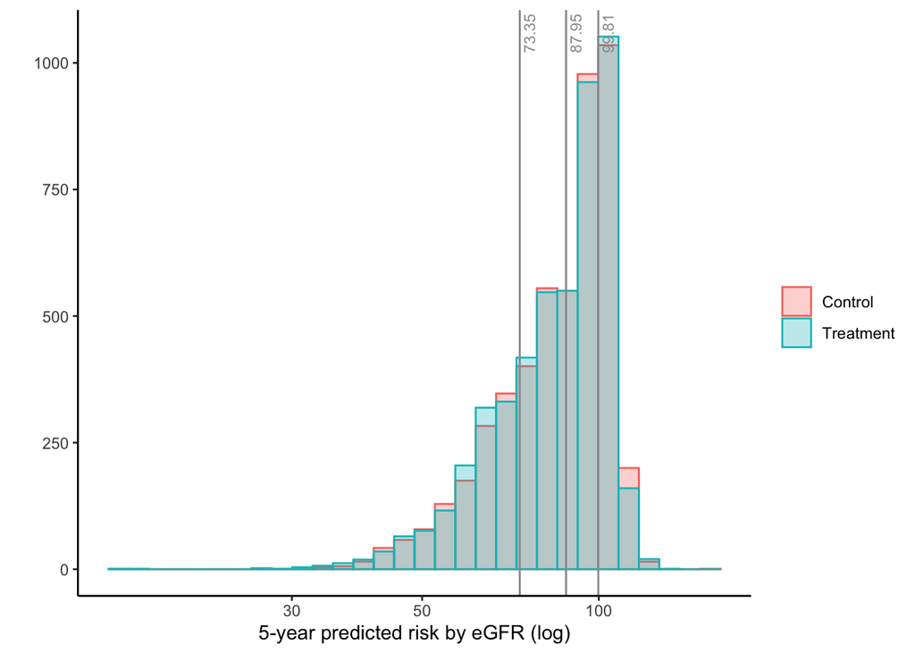

```r
# Calculate 5-year KFRE
df$kfre5 = with(df, {
  1 - 0.8996^exp(-0.2201 * (baseline_age/10 - 7.036) +
                   0.2467 * ((female==0) - 0.5642) -
                   0.5567 * (ckd2021GFR/5 - 7.222) +
                   0.4510 * ( log(uacr) - 5.137))
})

# kfre quartile thresholds
kfre_quart_thresh = quantile(df$kfre5, seq(0.25, 0.75, by = 0.25))
# Create groups based on thresholds
df$kfre_quarts = as.numeric(cut(df$kfre5,
                                breaks = c(-Inf, as.numeric(kfre_quart_thresh), Inf),
                                labels = c(1:(length(kfre_quart_thresh)+1))))

# eGFR quartile thresholds
egfr_quart_thresh = quantile(df$ckd2021GFR, seq(0.25, 0.75, by = 0.25))
# Create groups based on thresholds
df$egfr_quarts = as.numeric(cut(df$ckd2021GFR,
                                breaks = c(-Inf, as.numeric(egfr_quart_thresh), Inf),
                                labels = c(1:(length(egfr_quart_thresh)+1))))

# Histograms of eGFR for treatment and control
df %>%
  ggplot(aes(x = ckd2021GFR, fill = as.factor(glyarm), color = as.factor(glyarm))) +
  geom_histogram(alpha = 0.3, position="identity") +
  scale_x_log10() +
  geom_vline(xintercept = egfr_quart_thresh, color = "gray60") +
  geom_text(data = data.frame(egfr_quart_thresh = egfr_quart_thresh),
             aes(x = egfr_quart_thresh, y = Inf,
                 label = round(egfr_quart_thresh, 2)),
             inherit.aes = FALSE, color = "grey60",
            hjust = 1.1, vjust = 1.4, size = 3, angle = 90) +
  xlab("5-year predicted risk by eGFR (log)") + ylab("") +
  scale_fill_discrete(name = "", labels = c("0" = "Control", "1" = "Treatment")) +
  scale_color_discrete(name = "", labels = c("0" = "Control", "1" = "Treatment"))
```

```r
ggsave("figs_and_tabs/egfr_hist.png", width = 6, height = 4)

# Distribution of eGFR for treatment and control
egfr_dist_tab = data.frame(
  do.call(rbind, c(list(summary(df$ckd2021GFR)),
                 tapply(df$ckd2021GFR, df$glyarm, summary))),
  row.names = c("Overall", "Control", "Treatment")
)
names(egfr_dist_tab) = c("Min", "Q1", "Median", "Mean", "Q3", "Max")
write.csv(egfr_dist_tab %>% round(5), file = "figs_and_tabs/egfr_dist_tab.csv")
egfr_dist_tab %>% round(5)
```

```
##                Min       Q1   Median     Mean       Q3      Max
## Overall   15.37785 73.34831 87.94927 85.65832 99.81448 156.6843
## Control   33.42466 73.85182 88.11352 85.91308 99.92667 156.6843
## Treatment 15.37785 72.84823 87.71140 85.40516 99.76359 129.3931
```

These are summary statistics for the scores within each eGFR quartile.

```r
# General summary function that returns the mean, standard deviation, median
# and IQR of x
my_summary = function(x, na.rm = TRUE) {
  c("Mean" = mean(x, na.rm = na.rm),
    "SD" = sd(x, na.rm = na.rm),
    "Median" = median(x, na.rm = na.rm),
    "IQR" = IQR(x, na.rm = na.rm))
}

# Summary stats for eGFR within quartile
egfr_quart_tab = data.frame(do.call(rbind,
        lapply(1:4, function(i) {
          c(Quartile = i,
            my_summary(df$ckd2021GFR[df$egfr_quarts==i]))
        })
))
write.csv(egfr_quart_tab %>% round(5),
          file = "figs_and_tabs/egfr_quart_tab.csv", row.names = FALSE)
egfr_quart_tab %>% round(5)
```

```
##   Quartile      Mean      SD    Median      IQR
## 1        1  61.31824 9.09899  63.32249 12.66874
## 2        2  81.47278 4.17581  82.08775  7.14377
## 3        3  95.39723 3.37074  96.14687  4.98661
## 4        4 104.52765 4.23943 103.54508  4.94665
```

Median and IQR of baseline eGFR within each KFRE and baseline eGFR quartile.

```r
kfre_egfr_cross_tab = sapply(1:4, function(i) {
  out = sapply(1:4, function(j) {
    x = df$ckd2021GFR[df$kfre_quarts==i & df$egfr_quarts==j]
    paste0(round(median(x, na.rm = TRUE), 2), " (",
           round(IQR(x, na.rm = TRUE), 2),  ")")
  })
  names(out) = paste0("Baseline eGFR Q", 1:4)
  return(out)
}) %>% t() %>%
  data.frame(row.names = paste0("KFRE Q", 1:4)) %>%
  set_names(paste0("Baseline eGFR Q", 1:4))

write.csv(kfre_egfr_cross_tab,
          file = "figs_and_tabs/kfre_egfr_cross_tab.csv")
kfre_egfr_cross_tab
```

```
##         Baseline eGFR Q1 Baseline eGFR Q2 Baseline eGFR Q3 Baseline eGFR Q4
## KFRE Q1          NA (NA)          NA (NA)     97.97 (2.37)    104.05 (5.53)
## KFRE Q2          NA (NA)     85.47 (2.74)     95.37 (5.03)    102.28 (3.73)
## KFRE Q3     71.21 (2.69)     81.67 (6.56)     93.53 (7.43)     102.1 (2.52)
## KFRE Q4    61.71 (11.75)     76.76 (4.44)     89.16 (1.62)       100.13 (0)
```

Number of people in the KFRE and baseline eGFR quartiles.

```r
table(KFRE = df$kfre_quarts, "Baseline eGFR" = df$egfr_quarts)
```

```
##     Baseline eGFR
## KFRE    1    2    3    4
##    1    0    0  645 1800
##    2    0  440 1420  584
##    3  344 1682  362   56
##    4 2105  323   15    1
```

## Treatment effects

We estimate the 7-year RMST differences for each subgroup defined by the eGFR quartiles.

```r
# Horizon
horizon = 365*7

# RMST difference overall
overall_rmst_fits = lapply(outcome_list, function(x){
  df_sub = na.omit(df[,c(x["time"], x["status"], "glyarm", "egfr_quarts")])
  rmst2(df_sub[,x["time"]],
        df_sub[,x["status"]],
        df_sub[,"glyarm"],
        tau = horizon)
})
names(overall_rmst_fits) = names(outcome_list)
overall_rmst = sapply(names(outcome_list), function(outcome){
  overall_rmst_fits[[outcome]]$unadjusted.result[1,1]
})

# RMST difference by quartile
egfr_quart_rmst_fits = lapply(outcome_list, function(x){
  df_sub = na.omit(df[,c(x["time"], x["status"], "glyarm", "egfr_quarts")])
  lapply(1:4, function(i){
    rmst2(df_sub[df_sub$egfr_quarts==i,x["time"]],
          df_sub[df_sub$egfr_quarts==i,x["status"]],
          df_sub[df_sub$egfr_quarts==i,"glyarm"],
          tau = horizon)
  })
})
names(egfr_quart_rmst_fits) = names(outcome_list)
egfr_quart_rmst = sapply(names(outcome_list), function(outcome){
  sapply(1:4, function(i){
    egfr_quart_rmst_fits[[outcome]][[i]]$unadjusted.result[1,1]
  })
})
```

We use 1000 bootstrap samples to obtain confidence intervals for the RMST differences. Tables of the RMST differences and normalized RMST differences (where the overall RMST difference is subtracted from each quartile’s estimate) with 95% bootstrap CIs are shown below.

```r
# Number of bootstraps/permutations
B = 1000
```

```r
boot_egfr_rmst = foreach::foreach(
  b = 1:B,
  .packages = c("survRM2")
  ) %dopar% {
    # Set seed
    set.seed(b)
    # Create bootstrap sample
    boot_idx = sample(nrow(df), replace= TRUE)
    df_boot = df[boot_idx,]

    # Calculate overall RMST difference
    overall_rmst = sapply(outcome_list, function(x){
      df_sub = na.omit(df_boot[,c(x["time"], x["status"], "glyarm", "egfr_quarts")])
      rmst2(df_sub[,x["time"]],
            df_sub[,x["status"]],
            df_sub[,"glyarm"],
            tau = horizon)$unadjusted.result[1,1]
      })

    # Calculate RMST difference for each quartile
    egfr_quart_rmst = sapply(outcome_list, function(x){
      df_sub = na.omit(df_boot[,c(x["time"], x["status"], "glyarm", "egfr_quarts")])
      sapply(1:4, function(i){
        rmst2(df_sub[df_sub$egfr_quarts==i,x["time"]],
              df_sub[df_sub$egfr_quarts==i,x["status"]],
              df_sub[df_sub$egfr_quarts==i,"glyarm"],
              tau = horizon)$unadjusted.result[1,1]
      })
    })
    return(list(overall_rmst = overall_rmst,
                egfr_quart_rmst = egfr_quart_rmst))
  }

save(boot_egfr_rmst, file = "boot_egfr_rmst.rData")
```

```r
# Data dictionary for nice variable names
dat_dict = data.frame(rbind(
  c("neph_composite", "Composite kidney outcome", "(yes/no)"),
  c("Neph2", "Development of macro-albuminuria", "(yes/no)"),
  c("Neph3", "Renal failure or ESRD (dialysis) or SCr>3.3", "(yes/no)"),
  c("ALLDEATH", "All cause death", "(yes/no)"),
  c("CVDEATH", "Cardiovascular death", "(yes/no)"),
  c("hypoglycemia", "1st assisted hypoglycemic event", "(yes/no)")
))
names(dat_dict) = c("short", "long", "units")

# Overall
egfr_overall_rmst_boot_ci = apply(
  sapply(boot_egfr_rmst, function(x){
    x$overall_rmst
  }), 1, quantile, c(0.025, 0.975))

# Not normalized
egfr_quart_rmst_boot_ci = lapply(1:4, function(i){
  dat = sapply(boot_egfr_rmst, function(x){
    x$egfr_quart_rmst[i,]
  })
  apply(dat, 1, quantile, c(0.025, 0.975))
})

# Make tables
egfr_quart_rmst_boot_tabs = lapply(names(outcome_list), function(outcome){
  out = rbind(
    data.frame(Quartile = "Overall",
               "Est" = overall_rmst[outcome],
               t(egfr_overall_rmst_boot_ci[,outcome])),
    data.frame(Quartile = 1:4,
               "Est" = egfr_quart_rmst[,outcome],
               t(sapply(egfr_quart_rmst_boot_ci, function(x){x[,outcome]}))))
  rownames(out) = NULL
  return(out)
})
names(egfr_quart_rmst_boot_tabs) = names(outcome_list)

# Format table for printing
rmst_tab = data.frame(
  Outcome = rep(names(egfr_quart_rmst_boot_tabs),
                each = nrow(egfr_quart_rmst_boot_tabs[[1]])),
  do.call(rbind, egfr_quart_rmst_boot_tabs),
  row.names = NULL
)
rmst_tab = merge(dat_dict[,c("short", "long")], rmst_tab,
                 by.x = "short", by.y = "Outcome", all.y = TRUE,
                 sort = FALSE)[,-1]
names(rmst_tab) = c("Outcome", "Quartile", "Est", "2.5%", "97.5%")
rmst_tab[,c("Est", "2.5%", "97.5%")] =
  round(rmst_tab[,c("Est", "2.5%", "97.5%")], 2)
write.csv(rmst_tab,
          file = "figs_and_tabs/rmst_tab.csv", row.names = FALSE)
rmst_tab
```

```
##                                        Outcome Quartile     Est    2.5%   97.5%
## 1                     Composite kidney outcome  Overall   48.40   25.34   69.60
## 2                     Composite kidney outcome        1   85.74   33.73  136.41
## 3                     Composite kidney outcome        2   68.00   26.20  109.72
## 4                     Composite kidney outcome        3   25.93  -15.81   66.04
## 5                     Composite kidney outcome        4   22.81  -16.99   68.18
## 6             Development of macro-albuminuria  Overall   42.49   22.52   61.31
## 7             Development of macro-albuminuria        1   93.03   45.48  142.88
## 8             Development of macro-albuminuria        2   48.51   10.42   87.87
## 9             Development of macro-albuminuria        3   15.94  -21.63   49.71
## 10            Development of macro-albuminuria        4   22.28  -13.22   56.87
## 11 Renal failure or ESRD (dialysis) or SCr>3.3  Overall    5.43   -7.02   16.95
## 12 Renal failure or ESRD (dialysis) or SCr>3.3        1   -8.06  -34.52   17.00
## 13 Renal failure or ESRD (dialysis) or SCr>3.3        2   15.29   -6.21   37.75
## 14 Renal failure or ESRD (dialysis) or SCr>3.3        3   10.06  -13.39   31.81
```

[output cut: 16 more lines]

```r
# Normalized (subtract overall RMST difference)
egfr_quart_rmst_norm_boot_ci = lapply(1:4, function(i){
  dat = sapply(boot_egfr_rmst, function(x){
    x$egfr_quart_rmst[i,] - x$overall_rmst
  })
  apply(dat, 1, quantile, c(0.025, 0.975))
})

# Make tables
egfr_quart_rmst_boot_norm_tabs = lapply(names(outcome_list), function(outcome){
  data.frame(Quartile = 1:4,
               "Est" = egfr_quart_rmst[,outcome] - overall_rmst[outcome],
               t(sapply(egfr_quart_rmst_norm_boot_ci, function(x){x[,outcome]})))
})
names(egfr_quart_rmst_boot_norm_tabs) = names(outcome_list)

# Format table for printing
rmst_norm_tab = data.frame(
  Outcome = rep(names(egfr_quart_rmst_boot_norm_tabs),
                each = nrow(egfr_quart_rmst_boot_norm_tabs[[1]])),
  do.call(rbind, egfr_quart_rmst_boot_norm_tabs),
  row.names = NULL
)
rmst_norm_tab = merge(dat_dict[,c("short", "long")], rmst_norm_tab,
                      by.x = "short", by.y = "Outcome", all.y = TRUE,
                      sort = FALSE)[,-1]
names(rmst_norm_tab) = c("Outcome", "Quartile", "Est", "2.5%", "97.5%")
rmst_norm_tab[,c("Est", "2.5%", "97.5%")] =
  round(rmst_norm_tab[,c("Est", "2.5%", "97.5%")], 2)
write.csv(rmst_norm_tab,
          file = "figs_and_tabs/rmst_norm_tab.csv", row.names = FALSE)
rmst_norm_tab
```

```
##                                        Outcome Quartile    Est    2.5% 97.5%
## 1                     Composite kidney outcome        1  37.34   -5.01 80.70
## 2                     Composite kidney outcome        2  19.60  -16.83 56.65
## 3                     Composite kidney outcome        3 -22.47  -61.19 15.53
## 4                     Composite kidney outcome        4 -25.58  -63.26 13.06
## 5             Development of macro-albuminuria        1  50.55   13.52 91.15
## 6             Development of macro-albuminuria        2   6.02  -27.50 37.78
## 7             Development of macro-albuminuria        3 -26.55  -60.25  5.28
## 8             Development of macro-albuminuria        4 -20.21  -51.33 10.00
## 9  Renal failure or ESRD (dialysis) or SCr>3.3        1 -13.49  -35.38  8.68
## 10 Renal failure or ESRD (dialysis) or SCr>3.3        2   9.86  -10.01 30.95
## 11 Renal failure or ESRD (dialysis) or SCr>3.3        3   4.63  -16.59 23.36
## 12 Renal failure or ESRD (dialysis) or SCr>3.3        4  -0.45  -24.42 24.15
## 13                             All cause death        1  -9.17  -41.06 22.07
## 14                             All cause death        2  -0.37  -29.06 29.74
## 15                             All cause death        3  10.30  -19.72 42.72
## 16                             All cause death        4   3.08  -23.87 30.96
## 17                        Cardiovascular death        1  -2.70  -27.57 21.30
## 18                        Cardiovascular death        2  -1.41  -23.02 21.60
## 19                        Cardiovascular death        3   8.40  -14.56 27.71
## 20                        Cardiovascular death        4  -4.16  -24.41 15.61
## 21             1st assisted hypoglycemic event        1 -55.88 -104.60 -4.58
## 22             1st assisted hypoglycemic event        2  -6.00  -52.23 40.49
## 23             1st assisted hypoglycemic event        3  21.71  -24.87 65.87
## 24             1st assisted hypoglycemic event        4  46.03    1.11 85.36
```

These are plots of the RMST differences by outcome, with a horizontal reference line drawn at the overall/ATE point estimate. Shading denotes the ATE CI.

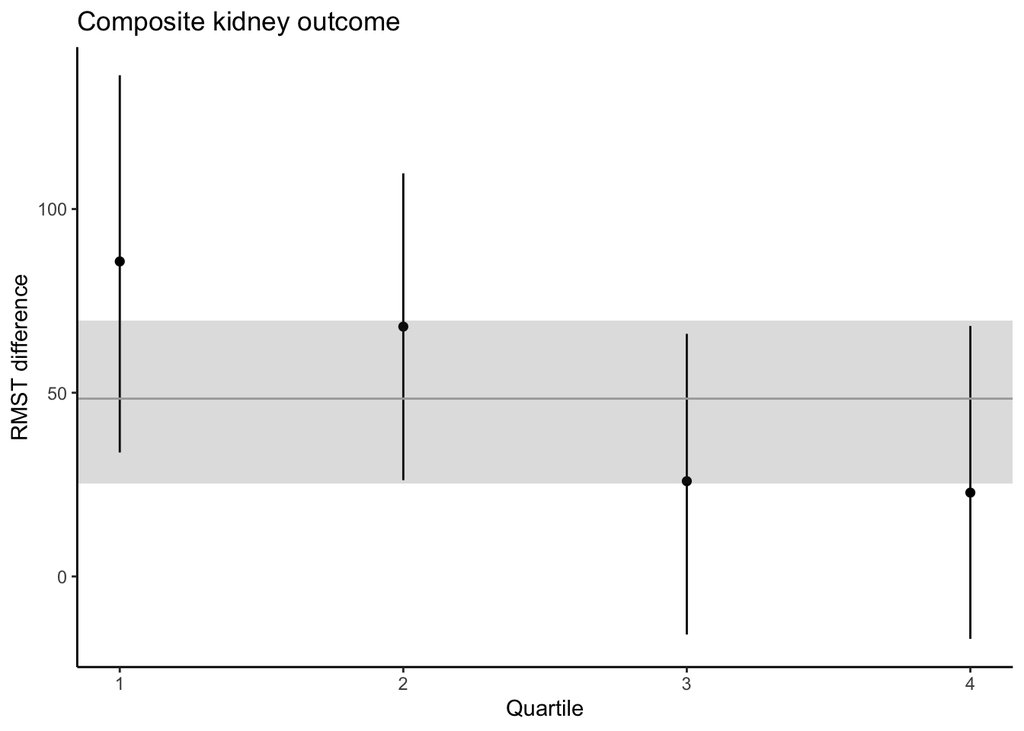

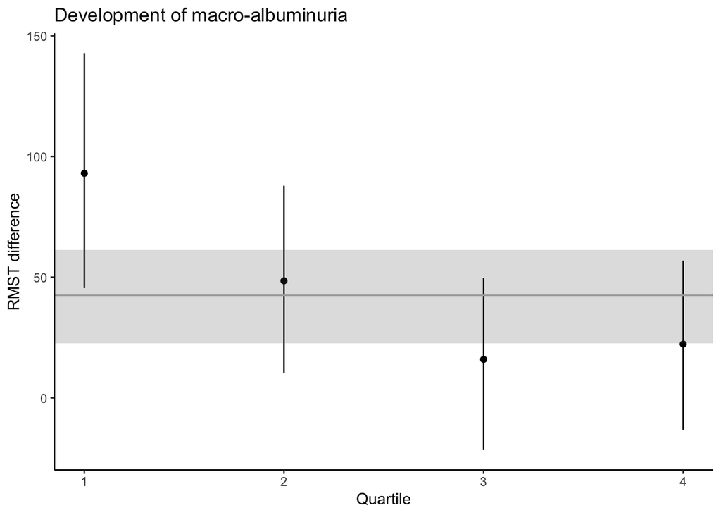

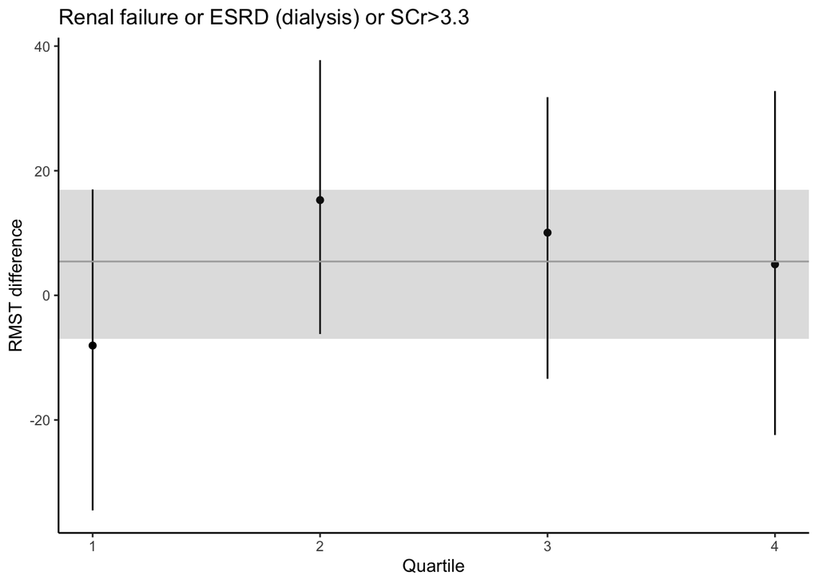

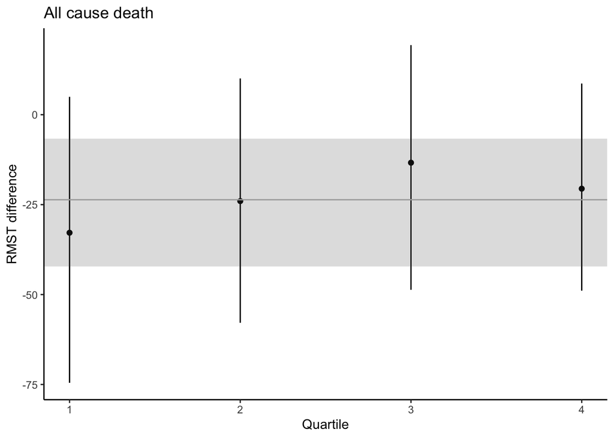

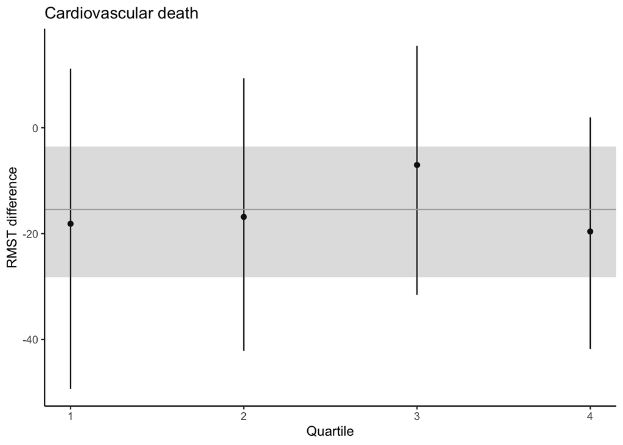

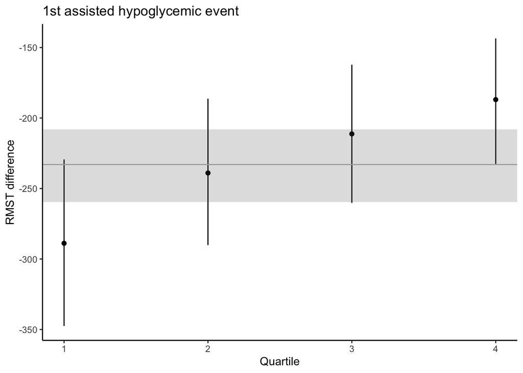

```r
for (outcome in names(egfr_quart_rmst_boot_tabs)) {
  ate_tab = egfr_quart_rmst_boot_tabs[[outcome]][1,]
  p1 = egfr_quart_rmst_boot_tabs[[outcome]][-1,] %>%
    mutate(x = 1:4) %>%
    ggplot(aes(x = x, y = as.numeric(Est))) +
    geom_pointrange(aes(ymin = X2.5., ymax = X97.5.), size = 0.25) +
    geom_hline(yintercept = ate_tab[,"Est"], color = "grey") +
    annotate("rect", xmin = -Inf, xmax = Inf,
             ymin = ate_tab[,"X2.5."], ymax = ate_tab[,"X97.5."],
             alpha = 0.2) +
    scale_x_continuous(breaks = 1:4, labels = 1:4) +
    theme(legend.position = 'bottom', legend.box = 'vertical') +
    xlab("Quartile") + ylab("RMST difference") +
    ggtitle(dat_dict$long[which(dat_dict$short == outcome)])
  print(p1)
  ggsave(paste0("figs_and_tabs/rmst_", outcome, ".png"),
         width = 6, height = 4)
}
```

Normalized RMST differences.

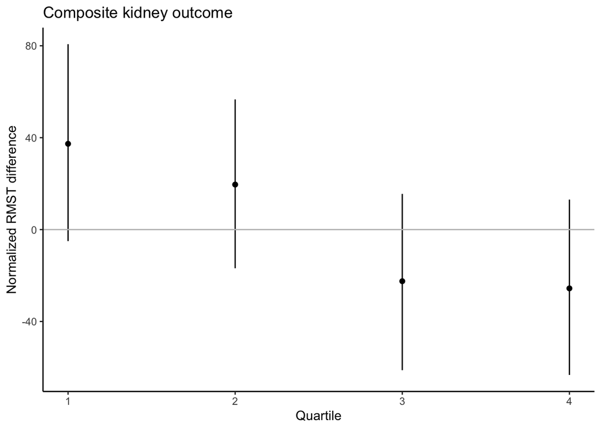

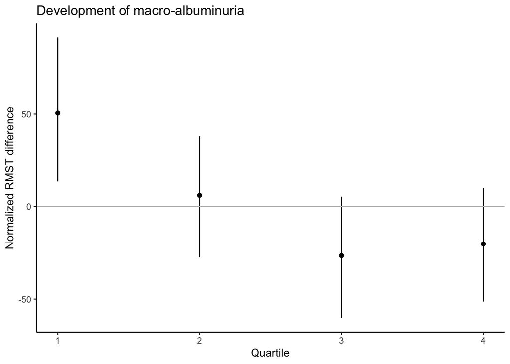

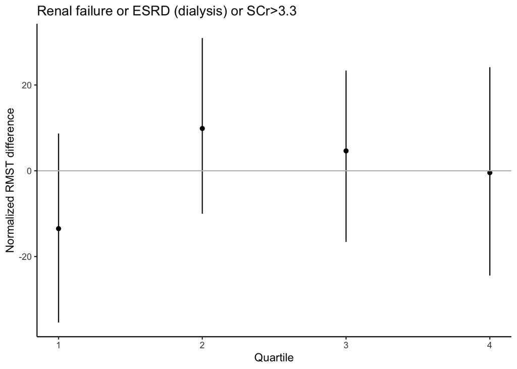

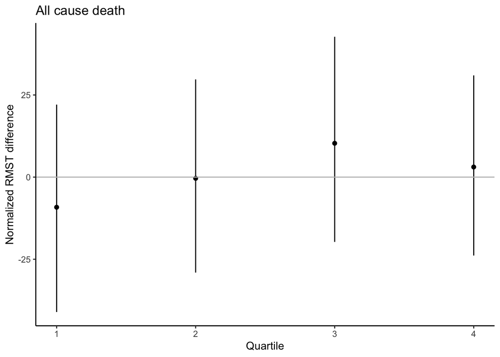

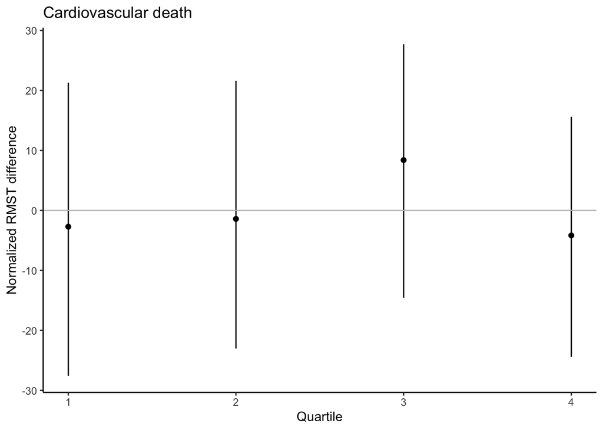

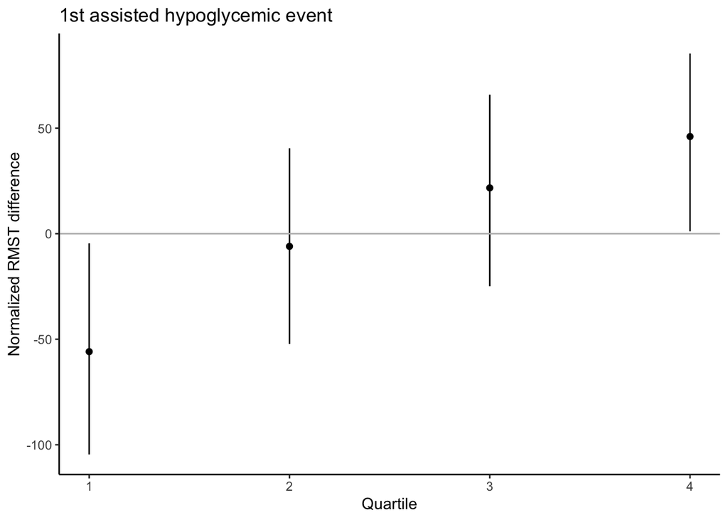

```r
for (outcome in names(egfr_quart_rmst_boot_norm_tabs)) {
  p1 = egfr_quart_rmst_boot_norm_tabs[[outcome]] %>%
    mutate(x = 1:4) %>%
    ggplot(aes(x = x, y = as.numeric(Est))) +
    geom_pointrange(aes(ymin = X2.5., ymax = X97.5.), size = 0.25) +
    scale_x_continuous(breaks = 1:4, labels = 1:4) +
    theme(legend.position = 'bottom', legend.box = 'vertical') +
    xlab("Quartile") + ylab("Normalized RMST difference") +
    geom_hline(yintercept = 0, color = "grey") +
    ggtitle(dat_dict$long[which(dat_dict$short == outcome)])
  print(p1)
  ggsave(paste0("figs_and_tabs/rmst_norm_", outcome, ".png"),
         width = 6, height = 4)
}
```

## eGFR slopes

Read in the longitudinal labs data and calculate eGFR.

```r
# Read in data
dir = "/Users/jliang/Library/CloudStorage/Box-Box/RELATE\ CKD/Study\ Datasets/ACCORD/ACCORD_2017b_2\ 2/Main_Study/3-Data_Sets-Analysis/3a-Analysis_Data_Sets/csv/"
activitystatus = read.csv(paste0(dir, "activitystatus.csv"))
otherlabs = read.csv(paste0(dir, "otherlabs.csv"))
accord_key = read.csv(paste0(dir, "accord_key.csv"))

# Calculate eGFR
calc_eGFR = function(AGE, MALE, SCR) {
  if (length(AGE) !=  length(MALE) ||
      length(AGE) !=  length(SCR) ||
      length(MALE) !=  length(SCR)) {
    warning("Input arguments are not the same length.")
  }

  kau = 0.7*(1 - MALE) + 0.9*MALE
  alpha = -0.241*(1 - MALE) - 0.302*MALE
  beta = 1.012*(1 - MALE) + 1*MALE

  return(142 * pmin(SCR/kau, 1)^alpha * pmax(SCR/kau, 1)^(-1.2) *
           0.9938^AGE * beta)
}

# Combine otherlabs (contains serum creatinine) with activitystatus (contains
# FU time) and accord_key (contains age, sex, and arm)
# Calculate eGFR and 4-month spline
# Only include observations with 7 years and for IDs included in the main df
egfr_df = right_join(activitystatus %>% select(MaskID, Visit, days_from_baseline),
                     otherlabs %>% select(MaskID, Visit, screat, gfr),
                     by = c("MaskID", "Visit")) %>%
  left_join(accord_key %>%
              select(MaskID, female, baseline_age, raceclass, arm, treatment),
            by = "MaskID") %>%
  mutate(treat = ifelse(arm %in% c(3, 4, 7, 8), 1, 0),
         baseline_age = baseline_age + days_from_baseline / 365) %>%
  mutate(egfr = calc_eGFR(baseline_age, female == 0, screat),
         days_from_baseline_165 =
           ifelse(days_from_baseline >= 165, 165, days_from_baseline),
         spline =
           ifelse(days_from_baseline >= 165, days_from_baseline - 165, 0)) %>%
  filter(days_from_baseline <= 365*7,
         MaskID %in% df$maskid) %>%
  drop_na()
```

```r
# Fit linear mixed model to eGFR with random intercepts and slopes to all patients,
# Include spline at 4 months
fit_egfr = lme(egfr ~ days_from_baseline_165 * treat + spline * treat,
               data = egfr_df,
               random = ~ 1 + spline + spline:treat | MaskID)

# Fit linear mixed model to eGFR with random intercepts and slopes to all
# patients, within each KFRS quartile
# Include spline at 4 months
fit_egfr_egfr_quarts = lapply(1:4, function(i) {
  lme(egfr ~ days_from_baseline_165 * treat + spline * treat,
      data = egfr_df %>% filter(egfr_quarts == i),
      random = ~ 1 + spline + spline:treat | MaskID,
      control = lmeControl(opt = "optim", optimMethod = "L-BFGS-B"))
})

# Save model fits
save(fit_egfr, fit_egfr_egfr_quarts, file = "fit_egfr.rData")
```

Using the slope coefficients from the model fits, we can calculate the mean eGFR slopes for the treatment and control arms, and the difference between arms. The total slope is taken as a weighted average of the acute and chronic slopes.

```r
# Extract coefficients from linear mixed models
coef_egfr = do.call(rbind, lapply(1:4, function(i) {
  as.data.frame(cbind(egfr_quarts = i, coef(fit_egfr_egfr_quarts[[i]])))
}))

# eGFR slopes from models fit by quartile, estimated for each individual
slope_df = data.frame(
  maskid = as.numeric(rownames(coef_egfr)),
  egfr_slope = 365 * ((4/84) * coef_egfr$`days_from_baseline_165:treat` +
    (80/84) * coef_egfr$`treat:spline`)
)

# Merge eGFR slopes with data frame
df = left_join(df, slope_df, by = "maskid")

# Calculate overall eGFR slope difference
overall_egfr = mean(df$egfr_slope)

# Calculate eGFR slope difference for each quartile
baseline_egfr_quart_egfr = sapply(1:4, function(i) {
  df_sub = df[df$egfr_quarts == i,]
  mean(df_sub$egfr_slope)
})
```

We use 1000 parametric bootstrap replicates to obtain confidence intervals for the eGFR slope differences. To do this, we repeatedly sample fixed and random effects from multivariate normal distributions (based on the estimates/covariances from the fitted model) to reconstruct a sample of slopes. Tables of the eGFR slope differences and normalized eGFR slope differences (where the overall eGFR slope difference is subtracted from each quartile’s estimate) with 95% bootstrap CIs are shown below.

```r
# Number of bootstraps
B = 1000

# Number of people in each quartile
n_baseline_egfr_quarts = as.numeric(table(df$egfr_quarts))
# Fixed effect estimates
fixed_eff = lapply(fit_egfr_egfr_quarts, fixed.effects)
# Fixed and random covariance matrices
fixed_cov_mat = lapply(fit_egfr_egfr_quarts, vcov)
random_cov_mat = lapply(fit_egfr_egfr_quarts, getVarCov)

boot_baseline_egfr_egfr = foreach::foreach(
  b = 1:B, .packages = c("tidyverse", "mvnfast")
  ) %dopar% {
    # Set seed
    set.seed(b)

    # Get data frame of slopes for each quartile
    slopes_by_quart = do.call(
      rbind,
      lapply(1:4, function(i) {
        # Randomly generate slopes by sampling from MVN
        n = n_baseline_egfr_quarts[i]
        fixed_samp = rmvn(n, mu = fixed_eff[[i]], sigma = fixed_cov_mat[[i]])
        colnames(fixed_samp) = names(fixed_eff[[i]])
        random_samp = rmvn(n, mu = rep(0, ncol(random_cov_mat[[i]])),
                           sigma = random_cov_mat[[i]])
        colnames(random_samp) = colnames(random_cov_mat[[i]])

        # Data frame of treatment/control slopes and slope difference
        data.frame(
          baseline_egfr_quarts = i,
          egfr_slope =
            365 * ((4/84) * fixed_samp[,"days_from_baseline_165:treat"] +
                     (80/84) * (fixed_samp[,"treat:spline"] + random_samp[,"spline:treat"])),
          Treatment = 365 * ((4/84) * (fixed_samp[,"days_from_baseline_165"] +
                                        fixed_samp[,"days_from_baseline_165:treat"]) +
                      (80/84) * (fixed_samp[,"spline"] + random_samp[,"spline"] +
                                   fixed_samp[,"treat:spline"] + random_samp[,"spline:treat"])),
          Control = 365 * ((4/84) * fixed_samp[,"days_from_baseline_165"] +
                             (80/84) * (fixed_samp[,"spline"] + random_samp[,"spline"]))
        )
    }))

    # Calculate overall slope_df slope difference
    overall_egfr = mean(slopes_by_quart$egfr_slope)

    # Calculate eGFR slope difference for each quartile
    baseline_egfr_quart_egfr = tapply(slopes_by_quart$egfr_slope,
                                      slopes_by_quart$baseline_egfr_quarts, mean)

    # Slope for each treatment arm  and quartile (used for plotting)
    egfr_lm_coefs = rbind(slopes_by_quart %>% mutate(baseline_egfr_quarts = "Overall"),
                          slopes_by_quart) %>%
      mutate(Quartile = factor(baseline_egfr_quarts, levels = c("Overall", 1:4))) %>%
      group_by(Quartile) %>%
      summarize(
        Treatment = mean(Treatment),
        Control = mean(Control)) %>%
      ungroup()

    return(list(overall_egfr = overall_egfr,
                baseline_egfr_quart_egfr = baseline_egfr_quart_egfr,
                egfr_lm_coefs = egfr_lm_coefs))
  }
```

```r
# Overall
baseline_egfr_overall_egfr_boot_ci = quantile(
  sapply(boot_baseline_egfr_egfr, function(x){
    x$overall_egfr
  }), c(0.025, 0.975))

# Not normalized
baseline_egfr_quart_egfr_boot_ci = sapply(1:4, function(i){
  quantile(sapply(boot_baseline_egfr_egfr, function(x){
    x$baseline_egfr_quart_egfr[i]
  }), c(0.025, 0.975))
})

# Make tables
baseline_egfr_quart_egfr_boot_tabs = rbind(
    data.frame(Quartile = "Overall",
               "Est" = overall_egfr,
               t(baseline_egfr_overall_egfr_boot_ci)),
    data.frame(Quartile = 1:4,
               "Est" = baseline_egfr_quart_egfr,
               t(baseline_egfr_quart_egfr_boot_ci)))

# Format table for printing
egfr_tab = baseline_egfr_quart_egfr_boot_tabs
rownames(egfr_tab) = NULL
names(egfr_tab) = c("Quartile", "Est", "2.5%", "97.5%")
egfr_tab[,c("Est", "2.5%", "97.5%")] =
  round(egfr_tab[,c("Est", "2.5%", "97.5%")], 5)
egfr_tab
```

```
##   Quartile     Est    2.5%   97.5%
## 1  Overall 0.36521 0.31747 0.41130
## 2        1 0.42607 0.32979 0.51952
## 3        2 0.40170 0.29642 0.50271
## 4        3 0.30774 0.20498 0.40443
## 5        4 0.32508 0.22389 0.43300
```

```r
# Normalized (subtract overall eGFR slope difference)
baseline_egfr_quart_egfr_norm_boot_ci = sapply(1:4, function(i){
  quantile(sapply(boot_baseline_egfr_egfr, function(x){
    x$baseline_egfr_quart_egfr[i] - x$overall_egfr
  }), c(0.025, 0.975))
})

# Make tables
baseline_egfr_quart_egfr_boot_norm_tabs =
  data.frame(Quartile = 1:4,
               "Est" = baseline_egfr_quart_egfr - overall_egfr,
               t(baseline_egfr_quart_egfr_norm_boot_ci))

# Format table for printing
egfr_norm_tab = baseline_egfr_quart_egfr_boot_norm_tabs
rownames(egfr_norm_tab) = NULL
names(egfr_norm_tab) = c("Quartile", "Est", "2.5%", "97.5%")
egfr_norm_tab[,c("Est", "2.5%", "97.5%")] =
  round(egfr_norm_tab[,c("Est", "2.5%", "97.5%")], 5)
egfr_norm_tab
```

```
##   Quartile      Est     2.5%   97.5%
## 1        1  0.06086 -0.01624 0.14917
## 2        2  0.03649 -0.05264 0.12759
## 3        3 -0.05746 -0.14384 0.02817
## 4        4 -0.04013 -0.12483 0.04991
```

These are plots of the eGFR slope differences, with a horizontal reference line drawn at the overall/ATE point estimate. Shading denotes the ATE CI.

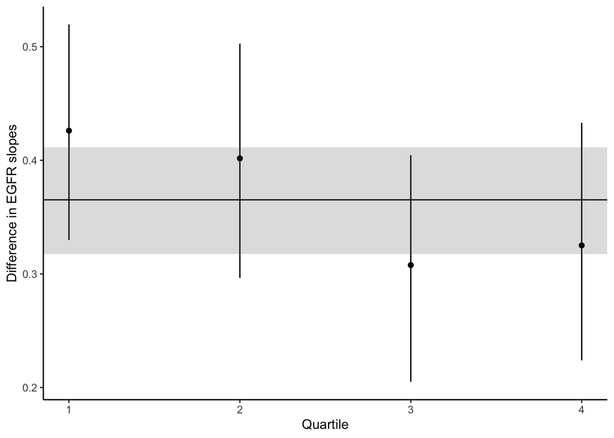

```r
baseline_egfr_quart_egfr_boot_tabs[-1,] %>%
  mutate(x = 1:4) %>%
  ggplot(aes(x = x, y = as.numeric(Est))) +
  geom_pointrange(aes(ymin = X2.5., ymax = X97.5.), size = 0.25) +
  geom_hline(data = baseline_egfr_quart_egfr_boot_tabs[1,], aes(yintercept = Est)) +
  geom_rect(data = baseline_egfr_quart_egfr_boot_tabs[1,],
            aes(x = NULL,y = NULL,
                xmin = -Inf, xmax = Inf,
                ymin = X2.5., ymax = X97.5.),
            alpha = 0.2) +
  theme(legend.position = 'bottom', legend.box = 'vertical') +
  xlab("Quartile") + ylab("Difference in EGFR slopes")
```

Normalized eGFR slope differences.

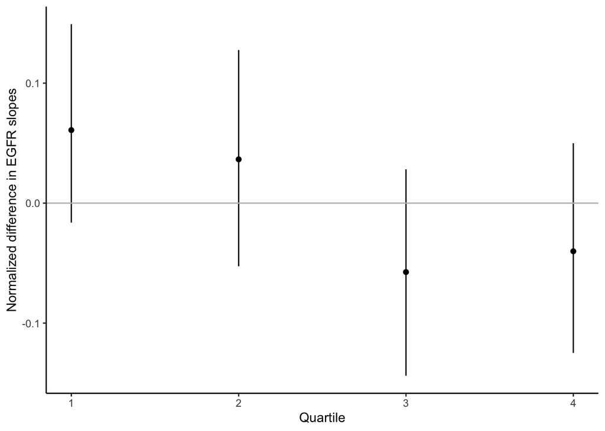

```r
baseline_egfr_quart_egfr_boot_norm_tabs %>%
    mutate(x = 1:4) %>%
    ggplot(aes(x = x, y = as.numeric(Est))) +
    geom_pointrange(aes(ymin = X2.5., ymax = X97.5.), size = 0.25) +
    theme(legend.position = 'bottom', legend.box = 'vertical') +
    xlab("Quartile") + ylab("Normalized difference in EGFR slopes") +
    geom_hline(yintercept = 0, color = "grey")
```